# BIOL343 Coding Challenge 6: Interactions, collinearity and false positives

Group 2 — names and student numbers in the chunk below

06 November 2026

# Group Members

```r
# Name - Queen's Student Number

# 1. Kaylee Ellwood - 20391007
# 2. Margo Kaminska - 20449041
# 3. Noah Lu - 20483156
# 4. Coralie Spakowski - 20471806
# 5. Tianyi Wang - 20386987
```

# DO THIS FIRST

Copy and paste these two lines into your R Console to install the current positpal, then **restart R** (*Session → Restart R*, or the restart button in the Console) before anything else. **Do not include them as a code chunk.**

```
install.packages("remotes")
remotes::install_url("https://quantitative.bio/downloads/positpal.tar.gz", upgrade = "never")
```

After the restart, paste this line, replacing `FILENAME.Rmd` with the name you are going to use for the .R or .Rmd file you are going to upload (rename the template first, e.g. `Group_#_CC6.Rmd`, and use that exact name):

```
positpal::start("FILENAME.Rmd")
```

Before you run it: create or open an R project folder for this challenge so that it is your working directory, then save this file in that folder under the name you will upload, and check that autosave is on (*File → Auto Save*). Closing the laptop or quitting Positron does not lose your log: when you reopen the project folder, positpal picks up where you left off and says so in the Console after your first command. **Every time you open Positron to work on this file, run the `start()` line again**, even if positpal says it picked up where you left off; it continues the same log and never erases it. See OnQ and use the positpal chatbot if you are having trouble with positpal.

# Part 1 — Import and inspect

The data file is `data/loosestrife.csv`: one row per stand of purple loosestrife (*Lythrum salicaria*) in Ontario, with the region, whether *Galerucella* beetles were released there, the site’s latitude and longitude, three measures of the plants, and the mean beetle damage index. The instructions describe the study, the variables and the three hypotheses. **Do not edit the file by hand.**

Last week you fitted models with one or two predictors that act *additively*. This week you will let predictors interact, see what happens when two predictors carry the same information, and count how often a test can be wrong.

As in earlier challenges, the tasks tell you **what** to produce, not which function to use. The starter lines in some chunks are commented out so that the blank template knits; remove the `#` as you fill them in.

# 1 Import and inspect the data

Import the data as an object called `lythrum` and check its structure. Then use `dplyr` to keep only the **Central** and **East** sites, save the result as `lythrum_ce`, and count the sites in each combination of region and release. Use `lythrum_ce` for the rest of the challenge.

```r
# library import
library(tidyverse)
# lythrum <-
lythrum <- read.csv(
  "/Users/coraliespakowski/Desktop/BIOL 343/BIOL343_CC6/data/loosestrife.csv"
)

# lythrum_ce <-
lythrum_ce <- lythrum %>%
  filter(when_any(region == "Central", region == "East"))

# count sites in each combination
lythrum_ce %>% count(region, release)
```

```
##    region    release  n
## 1 Central Nonrelease 17
## 2 Central    Release  3
## 3    East Nonrelease 14
## 4    East    Release  4
```

**Question 1:** How many sites are in each of the four combinations of region and release? Why might the small number of release sites be a problem when you test region and release in the same model?

**Answer:** There are 17 sites in Central-Nonrelease combination, 3 in Central-Release, 14 in East-Nonrelease, and 4 in East-Release. The small number of release sites might be a problem when you test region and release in the same model because less observations, less precise.

# Part 2 — Interaction terms

# 2 Two categorical predictors

Draw a boxplot of damage by region, filled by release, with axis labels and a clean theme. Calculate the mean damage of each of the four region × release groups. Then fit a linear model of damage with region, release **and their interaction** as predictors, and print the summary and the ANOVA table.

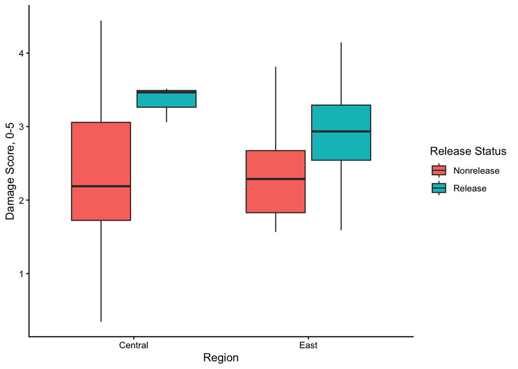

```r
# boxplot of damage by region
ggplot(data = lythrum_ce, aes(x = region, y = damage, fill = release)) +
  geom_boxplot() +
  theme_classic() +
  labs(x = "Region", y = "Damage Score, 0-5", fill = "Release Status")
```

```r
# calculate mean damage of each of the four region x release groups
calculated_mean_dmg <- lythrum_ce %>%
  group_by(region, release) %>%
  summarise(mean_damage = mean(damage, na.rm = TRUE), .groups = 'drop')
print(calculated_mean_dmg)
```

```
## # A tibble: 4 × 3
##   region  release    mean_damage
##   <chr>   <chr>            <dbl>
## 1 Central Nonrelease        2.20
## 2 Central Release           3.35
## 3 East    Nonrelease        2.37
## 4 East    Release           2.90
```

```r
# int_mod <-
int_mod <- lm(damage ~ region * release, data = lythrum_ce) # AND THEIR INTERACTIONS
summary(int_mod)
```

```
##
## Call:
## lm(formula = damage ~ region * release, data = lythrum_ce)
##
## Residuals:
##      Min       1Q   Median       3Q      Max
## -1.85564 -0.46394 -0.02735  0.51470  2.23944
##
## Coefficients:
##                           Estimate Std. Error t value Pr(>|t|)
## (Intercept)                 2.2020     0.2145  10.268  5.9e-12 ***
## regionEast                  0.1677     0.3191   0.526   0.6026
## releaseRelease              1.1456     0.5537   2.069   0.0462 *
## regionEast:releaseRelease  -0.6140     0.7469  -0.822   0.4168
## ---
## Signif. codes:  0 '***' 0.001 '**' 0.01 '*' 0.05 '.' 0.1 ' ' 1
##
## Residual standard error: 0.8842 on 34 degrees of freedom
## Multiple R-squared:  0.1406, Adjusted R-squared:  0.06477
## F-statistic: 1.854 on 3 and 34 DF,  p-value: 0.156
```

```r
anova(int_mod)
```

```
## Analysis of Variance Table
##
## Response: damage
##                Df  Sum Sq Mean Sq F value Pr(>F)
## region          1  0.1232  0.1232  0.1576 0.6939
## release         1  3.6977  3.6977  4.7294 0.0367 *
## region:release  1  0.5283  0.5283  0.6757 0.4168
## Residuals      34 26.5837  0.7819
## ---
## Signif. codes:  0 '***' 0.001 '**' 0.01 '*' 0.05 '.' 0.1 ' ' 1
```

**Question 2:** Using only the estimates in the summary, calculate the mean damage of each of the four groups, and check them against the four group means you calculated at the start of this task. Is the interaction positive (synergistic) or negative (antagonistic), and is it significant? What do you conclude about hypotheses 1 and 2?

**Answer:** Calculated means: Central Nonrelease 2.20 Central Release 3.35 East Nonrelease 2.37 East Release 2.90

Calculating means using summary estimates: Central-Nonrelease: 2.2020 Central-Release: 2.2020 + 1.1456 = 3.3476 East-Nonrelease: 2.2020 + 0.1677 = 2.3697 East-Release: 2.2020 + 1.1456 + 0.1677 - 0.6140 = 2.9013

The interaction between region and release was negative (-0.6140), but it was not statistically significant (p = 0.4168). This indicates that there is insufficient evidence that the effect of biocontrol agent release on beetle damage differs between the Central and East regions.

Regarding the hypotheses, Hypothesis 1 was not supported because beetle damage was not significantly different between the Central and East regions (p = 0.6939), despite the observed means being slightly lower in Central. Hypothesis 2 was supported because beetle damage was significantly higher at release sites than at nonrelease sites (p = 0.0367).

# 3 A continuous and a categorical predictor

Plot damage (y) against latitude (x), coloured by release, with a fitted straight line for each release group, axis labels with units, a legend title and a clean theme. Then fit a linear model of damage with latitude, release and their interaction as predictors, and print the summary and the ANOVA table.

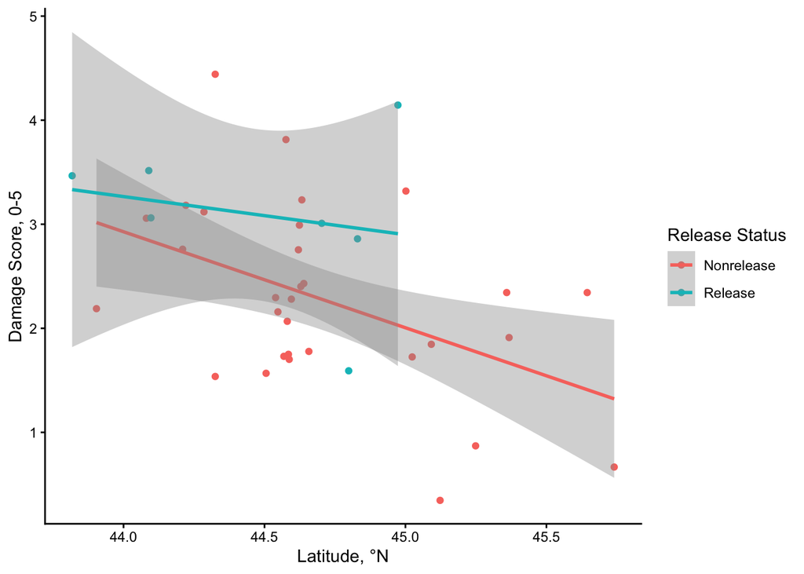

```r
# plotting damage against latitude
ggplot(data = lythrum_ce, aes(y = damage, x = latitude, colour = release)) +
  geom_point() +
  labs(y = "Damage Score, 0-5", x = "Latitude, °N", colour = "Release Status") +
  theme_classic() +
  geom_smooth(method = "lm", formula = y ~ x)
```

```r
# lat_mod <-
lat_mod <- lm(damage ~ latitude * release, data = lythrum_ce)
summary(lat_mod)
```

```
##
## Call:
## lm(formula = damage ~ latitude * release, data = lythrum_ce)
##
## Residuals:
##      Min       1Q   Median       3Q      Max
## -1.54544 -0.61446 -0.03687  0.44032  1.81369
##
## Coefficients:
##                         Estimate Std. Error t value Pr(>|t|)
## (Intercept)              43.5218    14.9103   2.919  0.00619 **
## latitude                 -0.9226     0.3335  -2.766  0.00910 **
## releaseRelease          -24.1305    35.2608  -0.684  0.49840
## latitude:releaseRelease   0.5561     0.7921   0.702  0.48741
## ---
## Signif. codes:  0 '***' 0.001 '**' 0.01 '*' 0.05 '.' 0.1 ' ' 1
##
## Residual standard error: 0.8047 on 34 degrees of freedom
## Multiple R-squared:  0.2882, Adjusted R-squared:  0.2254
## F-statistic: 4.589 on 3 and 34 DF,  p-value: 0.008395
```

```r
anova(lat_mod)
```

```
## Analysis of Variance Table
##
## Response: damage
##                  Df  Sum Sq Mean Sq F value   Pr(>F)
## latitude          1  6.4661  6.4661  9.9852 0.003307 **
## release           1  2.1304  2.1304  3.2899 0.078542 .
## latitude:release  1  0.3192  0.3192  0.4929 0.487413
## Residuals        34 22.0172  0.6476
## ---
## Signif. codes:  0 '***' 0.001 '**' 0.01 '*' 0.05 '.' 0.1 ' ' 1
```

**Question 3:** Write the fitted equation (intercept and slope) for the non-release sites and for the release sites. What does the interaction estimate mean in this model? Is there evidence that the slope of damage against latitude differs between release and non-release sites?

**Answer:**

Nonrelease sites: $Damage = 43.5218 - 0.9226(latitude)$ Release sites: $Damage = 19.3913 - 0.3665(latitude)$

The interaction estimate is 0.5561, meaning that the slope of damage against latitude is 0.5561 units more positive at release sites compared to non-release sites. This indicates that damage decreases less steeply with increasing latitude at release sites.

However, there is no statistically significant evidence that the slopes differ between release and non-release sites (p = 0.48741), since the p-value is greater than 0.05. Therefore, we cannot conclude that the relationship between latitude and beetle damage differs depending on whether biocontrol agents were released.

# Part 3 — Collinearity

# 4 Region and longitude

Plot longitude by region. Calculate the correlations among the five continuous columns (latitude, longitude and the three plant measures). Then fit three linear models of damage: one with region as the only predictor, one with longitude as the only predictor, and one with both, and print the three summaries.

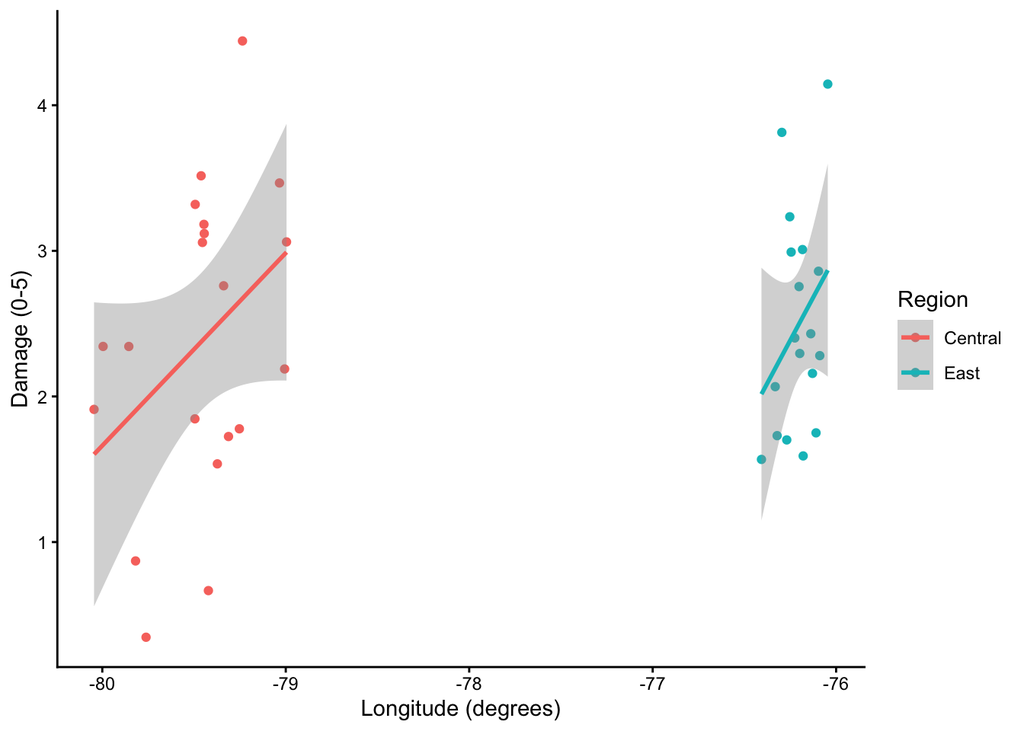

```r
# plot longitude by region
ggplot(data = lythrum_ce, aes(y = damage, x = longitude, colour = region)) +
  geom_point() +
  labs(x = "Longitude (degrees)", y = "Damage (0-5)", colour = "Region") +
  theme_classic() +
  geom_smooth(method = "lm", formula = y ~ x)
```

```r
# calculate correlations amond the five continuous columns
lythrum_ce %>%
  select(latitude, longitude, stemsper50m2, stemheight_cm, inflorescences) %>%
  cor()
```

```
##                  latitude   longitude stemsper50m2 stemheight_cm inflorescences
## latitude        1.0000000 -0.13496455 -0.135544862   -0.21992344   -0.363621847
## longitude      -0.1349646  1.00000000  0.261040033    0.08381715    0.431154673
## stemsper50m2   -0.1355449  0.26104003  1.000000000    0.10956873   -0.001909662
## stemheight_cm  -0.2199234  0.08381715  0.109568730    1.00000000    0.375188489
## inflorescences -0.3636218  0.43115467 -0.001909662    0.37518849    1.000000000
```

```r
# fit three linear models of damage:
# region
lm_region <- lm(damage ~ region, lythrum_ce)
# longitude
lm_longitude <- lm(damage ~ longitude, lythrum_ce)
# region and longitude
lm_both <- lm(damage ~ region + longitude, lythrum_ce)
# print summaries
summary(lm_region)
```

```
##
## Call:
## lm(formula = damage ~ region, data = lythrum_ce)
##
## Residuals:
##      Min       1Q   Median       3Q      Max
## -2.02748 -0.63578 -0.07173  0.68659  2.06759
##
## Coefficients:
##             Estimate Std. Error t value Pr(>|t|)
## (Intercept)   2.3738     0.2069  11.476 1.39e-13 ***
## regionEast    0.1140     0.3006   0.379    0.707
## ---
## Signif. codes:  0 '***' 0.001 '**' 0.01 '*' 0.05 '.' 0.1 ' ' 1
##
## Residual standard error: 0.9251 on 36 degrees of freedom
## Multiple R-squared:  0.003982,   Adjusted R-squared:  -0.02368
## F-statistic: 0.1439 on 1 and 36 DF,  p-value: 0.7066
```

```r
summary(lm_longitude)
```

```
##
## Call:
## lm(formula = damage ~ longitude, data = lythrum_ce)
##
## Residuals:
##     Min      1Q  Median      3Q     Max
## -1.9698 -0.6063 -0.1171  0.7035  2.0934
##
## Coefficients:
##             Estimate Std. Error t value Pr(>|t|)
## (Intercept)  7.15310    7.09886   1.008     0.32
## longitude    0.06064    0.09108   0.666     0.51
##
## Residual standard error: 0.9213 on 36 degrees of freedom
## Multiple R-squared:  0.01216,    Adjusted R-squared:  -0.01528
## F-statistic: 0.4433 on 1 and 36 DF,  p-value: 0.5098
```

```r
summary(lm_both)
```

```
##
## Call:
## lm(formula = damage ~ region + longitude, data = lythrum_ce)
##
## Residuals:
##      Min       1Q   Median       3Q      Max
## -1.76406 -0.68322 -0.01467  0.64388  1.74902
##
## Coefficients:
##             Estimate Std. Error t value Pr(>|t|)
## (Intercept) 114.3125    50.5528   2.261   0.0301 *
## regionEast   -4.4719     2.0906  -2.139   0.0395 *
## longitude     1.4087     0.6362   2.214   0.0334 *
## ---
## Signif. codes:  0 '***' 0.001 '**' 0.01 '*' 0.05 '.' 0.1 ' ' 1
##
## Residual standard error: 0.8787 on 35 degrees of freedom
## Multiple R-squared:  0.1264, Adjusted R-squared:  0.07645
## F-statistic: 2.531 on 2 and 35 DF,  p-value: 0.09402
```

**Question 4:** Which two predictors are collinear, and why would you expect that from how the regions are defined? Does your correlation table show it? Compare the estimates, standard errors and *p*-values for region and longitude across the three models. Why does the model with both predictors find “significant” effects that neither predictor shows alone? Which predictor would you keep, and why?

**Answer:**

The two predictors that are likely collinear are region and longitude. This is expected because the Central and East regions are geographically separated, meaning that longitude is likely strongly associated with which region a site belongs to. The correlation table does not directly show this relationship because region is categorical and was not included in the correlation analysis.

When examining the three models, neither region alone (p = 0.707) nor longitude alone (p = 0.510) significantly explained beetle damage. However, when both predictors were included, region (p = 0.0395) and longitude (p = 0.0334) became statistically significant. Their coefficient estimates also changed considerably.

This occurs because region and longitude share explanatory information. Including both predictors allows the model to estimate the effect of each while accounting for the other, potentially revealing conditional relationships that were not apparent when the predictors were examined separately. However, the substantial changes in the estimates suggest possible multicollinearity, which can make the individual coefficients unstable.

I would keep region and remove longitude because region is more directly related to the biological hypothesis being investigated and is easier to interpret.

# Part 4 — False positives and model accuracy

# 5 Three tests of hypothesis 3

Hypothesis 3 says that beetle damage reduces the abundance of the plant and changes its growth form. Fit three linear models, one for each plant measure (stem density, stem height and inflorescences) as the response, each with damage as the only predictor, and print the three summaries.

```r
# linear model for stem density with damage as predictor
lm_density <- lm(stemsper50m2 ~ damage, lythrum_ce)

# linear model for stem height with damage as predictor
lm_height <- lm(stemheight_cm ~ damage, lythrum_ce)

# linear model for inflorescence with damage as predictor
lm_inflo <- lm(inflorescences ~ damage, lythrum_ce)

# print summaries
summary(lm_density)
```

```
##
## Call:
## lm(formula = stemsper50m2 ~ damage, data = lythrum_ce)
##
## Residuals:
##     Min      1Q  Median      3Q     Max
## -146.52  -85.57  -41.26   46.83  413.55
##
## Coefficients:
##             Estimate Std. Error t value Pr(>|t|)
## (Intercept)   104.65      58.56   1.787   0.0823 .
## damage         12.27      22.61   0.543   0.5906
## ---
## Signif. codes:  0 '***' 0.001 '**' 0.01 '*' 0.05 '.' 0.1 ' ' 1
##
## Residual standard error: 125.7 on 36 degrees of freedom
## Multiple R-squared:  0.008117,   Adjusted R-squared:  -0.01944
## F-statistic: 0.2946 on 1 and 36 DF,  p-value: 0.5906
```

```r
summary(lm_height)
```

```
##
## Call:
## lm(formula = stemheight_cm ~ damage, data = lythrum_ce)
##
## Residuals:
##     Min      1Q  Median      3Q     Max
## -57.005 -11.247   0.573  12.482  39.341
##
## Coefficients:
##             Estimate Std. Error t value Pr(>|t|)
## (Intercept)  117.415     10.177  11.537 1.19e-13 ***
## damage         1.216      3.929   0.309    0.759
## ---
## Signif. codes:  0 '***' 0.001 '**' 0.01 '*' 0.05 '.' 0.1 ' ' 1
##
## Residual standard error: 21.85 on 36 degrees of freedom
## Multiple R-squared:  0.002651,   Adjusted R-squared:  -0.02505
## F-statistic: 0.09571 on 1 and 36 DF,  p-value: 0.7588
```

```r
summary(lm_inflo)
```

```
##
## Call:
## lm(formula = inflorescences ~ damage, data = lythrum_ce)
##
## Residuals:
##     Min      1Q  Median      3Q     Max
## -4.4959 -2.2125 -0.2706  1.1418  7.3569
##
## Coefficients:
##             Estimate Std. Error t value Pr(>|t|)
## (Intercept)   3.1404     1.4545   2.159   0.0376 *
## damage        0.8230     0.5616   1.466   0.1514
## ---
## Signif. codes:  0 '***' 0.001 '**' 0.01 '*' 0.05 '.' 0.1 ' ' 1
##
## Residual standard error: 3.123 on 36 degrees of freedom
## Multiple R-squared:  0.05631,    Adjusted R-squared:  0.0301
## F-statistic: 2.148 on 1 and 36 DF,  p-value: 0.1514
```

**Question 5:** Do any of the three models support hypothesis 3? Suppose damage had no effect at all on any of the three measures. What is the probability that at least one of three independent tests gives *p* < 0.05 by chance? What does that mean for a study that tests many responses or many predictors?

**Answer:**

None of the three models supports Hypothesis 3 because none of the relationships between beetle damage and the plant characteristics (stem density, stem height, and inflorescence number) was statistically significant. All three p-values were greater than 0.05.

If damage had no effect on any of the three measures and the tests were independent, the probability of obtaining at least one significant result by chance would be 1 - (0.95)³ = 0.1426, or approximately 14.26%. What this means is that for a study that tests many responses/predictors, there is an inflation of type I errors (false positives). Therefore, studies that test many responses or predictors should consider using multiple-testing corrections, such as the Bonferroni or Holm correction, to reduce the risk of incorrectly identifying significant relationships.

# 6 How good is a quick field check?

A manager suggests a cheap way to tell whether beetles were released at a site without checking the records: call it a release site if its damage index is **3 or more**. Add a column to `lythrum_ce` with this prediction, and make a table of the predicted against the actual release status. Treating “release” as a positive result, count the true positives, false positives, true negatives and false negatives, and calculate the accuracy, sensitivity, specificity and false discovery rate of the check.

```r
# new prediction column
lythrum_ce <- lythrum_ce %>%
  mutate(predicted_release = ifelse(damage >= 3, "Release", "Nonrelease"))

# table of predicted against actual
table(Predicted = lythrum_ce$predicted_release, Actual = lythrum_ce$release)
```

```
##             Actual
## Predicted    Nonrelease Release
##   Nonrelease         24       2
##   Release             7       5
```

```r
# count true positives, false positives, true negatives, and false negatives
results <- lythrum_ce %>%
  summarise(
    TP = sum(predicted_release == "Release" & release == "Release"),
    FP = sum(predicted_release == "Release" & release == "Nonrelease"),
    TN = sum(predicted_release == "Nonrelease" & release == "Nonrelease"),
    FN = sum(predicted_release == "Nonrelease" & release == "Release")
  )

# calculate accuracy, sensitivity, specificity, and false discovery rate
results <- results %>%
  mutate(
    accuracy = (TP + TN) / (TP + FP + TN + FN),
    sensitivity = TP / (TP + FN),
    specificity = TN / (TN + FP),
    false_discovery_rate = FP / (TP + FP)
  )

# display results
results
```

```
##   TP FP TN FN  accuracy sensitivity specificity false_discovery_rate
## 1  5  7 24  2 0.7631579   0.7142857   0.7741935            0.5833333
```

**Question 6:** Report the four rates. Why is the false discovery rate so much higher than you might expect from the accuracy? If the manager’s goal is to find **every** release site so that it can be monitored, should the check be more sensitive or more specific, and which way would you move the threshold of 3?

**Answer:**

The four classification rates are accuracy, sensitivity, specificity, and false discovery rate, calculated from the confusion matrix. Accuracy measures the overall proportion of correctly classified sites, while the false discovery rate measures the proportion of sites predicted to be release sites that were actually nonrelease sites.

The false discovery rate can be relatively high despite reasonable accuracy because release sites may be less common than nonrelease sites. Therefore, false positives can represent a large proportion of all sites predicted to be release sites, even if most sites overall are classified correctly.

If the manager’s goal is to identify every release site for monitoring, the check should prioritize sensitivity over specificity. High sensitivity reduces the number of false negatives, meaning fewer actual release sites are missed. I would therefore lower the damage threshold from 3. This would classify more sites as release sites, increasing the likelihood of identifying all actual release sites, although it may also increase false positives.

# DO THIS LAST

When your document is finished, knit it, open the `.html` in a web browser and **print it to PDF** (*File → Print → Save as PDF*; name it `Group_#_CC6.pdf`). Then copy and paste this into the R Console to stop positpal and create your coding log. **Do not include it as a code chunk.**

```
positpal::stop_capture()
positpal::export_capture()
```

`export_capture()` prints the name and location of the `my-capture-YYYYMMDD-HHMMSS.zip` it creates beside this file. **Each group member** uploads their own `.zip` to the **“CC6 — Coding Log (individual)”** dropbox on OnQ; the group’s `.Rmd` and the **`.pdf`** (not the `.html` — OnQ shows uploaded HTML as source code, not as a page) go to your section’s **TUT02-CC6** or **TUT03-CC6** folder. Submissions without the log are incomplete. If `export_capture()` fails, zip the `.capture` folder yourself and upload that instead.